# Predicción de Abandono de Clientes Utilizando Técnicas de Machine Learning y Deep Learning

### 3.6 Correlación de Características Independientes

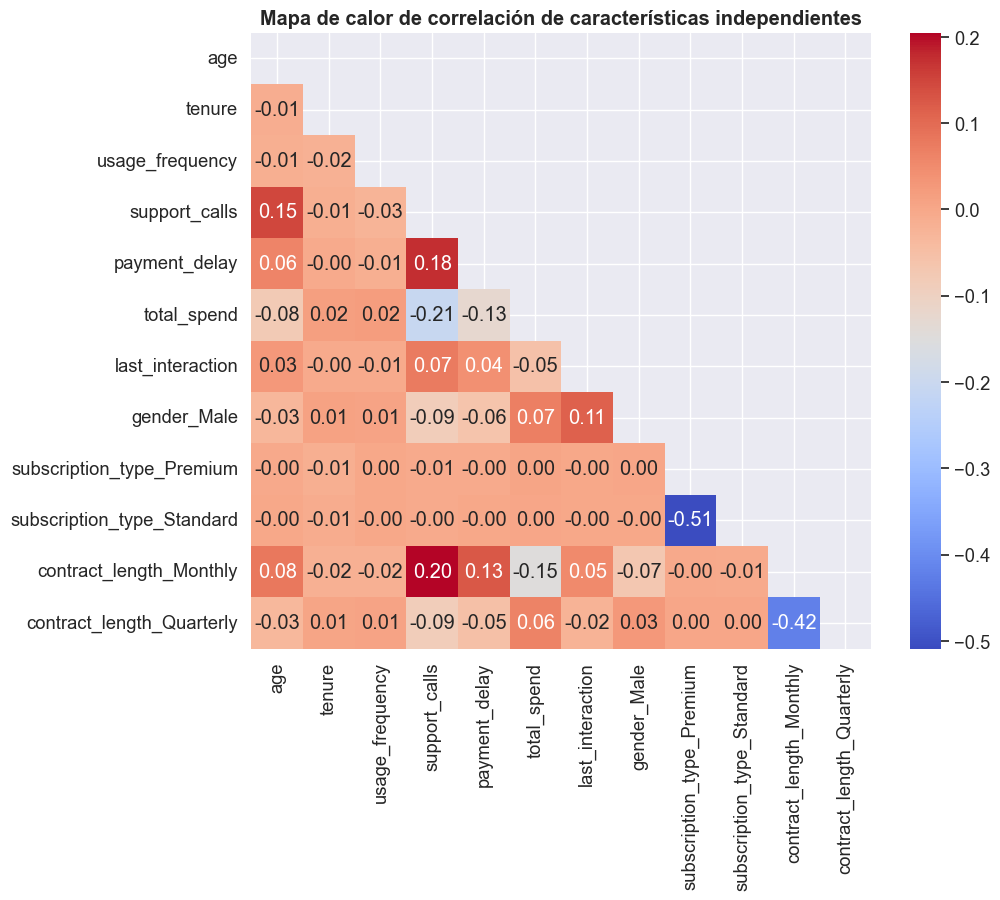

### Relaciones clave entre variables

**Llamadas de soporte y retraso en el pago (0.18):**  
Existe una correlación positiva moderada entre el número de llamadas al soporte y el retraso en los pagos. Esto sugiere que los clientes que tienen retrasos en el pago tienden a requerir más llamadas al soporte, posiblemente debido a problemas o insatisfacción.

**Gasto total y llamadas de soporte (-0.21):**  
Hay una correlación negativa moderada entre el gasto total y las llamadas al soporte. Los clientes que gastan más en el servicio parecen necesitar menos soporte, lo que podría indicar una experiencia más satisfactoria o menos problemas técnicos.

**Duración del contrato mensual y llamadas de soporte (0.20):**  
Existe una correlación positiva moderada entre los contratos mensuales y las llamadas al soporte. Esto sugiere que los clientes con contratos mensuales pueden experimentar más problemas o requerir más asistencia.

**Género_Masculino y última_interacción (0.11):**  
La correlación positiva leve indica que los hombres tienen una ligera tendencia a tener interacciones más recientes en comparación con las mujeres.

**Tipo de suscripción_Estándar y tipo de suscripción_Premium (-0.51):**  
Existe una fuerte correlación negativa entre estos dos tipos de suscripción, lo cual es lógico, ya que son mutuamente excluyentes.

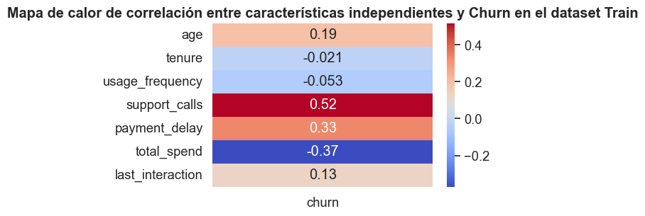

|  | age | tenure | usage_frequency | support_calls | payment_delay | total_spend | last_interaction | gender_Male | subscription_type_Premium | subscription_type_Standard | contract_length_Monthly | contract_length_Quarterly |
| --- | --- | --- | --- | --- | --- | --- | --- | --- | --- | --- | --- | --- |
| 207572 | 21.0 | 37.0 | 20.0 | 7.0 | 16.0 | 491.11 | 1.0 | 1 | 0 | 1 | 1 | 0 |
| 69416 | 50.0 | 52.0 | 9.0 | 3.0 | 9.0 | 363.00 | 5.0 | 0 | 1 | 0 | 0 | 1 |
| 207784 | 44.0 | 55.0 | 3.0 | 3.0 | 27.0 | 258.02 | 20.0 | 1 | 0 | 1 | 0 | 1 |
| 77631 | 65.0 | 25.0 | 18.0 | 4.0 | 10.0 | 130.00 | 18.0 | 1 | 1 | 0 | 0 | 0 |
| 397816 | 47.0 | 32.0 | 8.0 | 4.0 | 12.0 | 794.14 | 13.0 | 0 | 1 | 0 | 0 | 1 |
| ... | ... | ... | ... | ... | ... | ... | ... | ... | ... | ... | ... | ... |
| 4832 | 55.0 | 60.0 | 18.0 | 7.0 | 2.0 | 424.00 | 30.0 | 0 | 1 | 0 | 0 | 1 |
| 383300 | 18.0 | 9.0 | 19.0 | 1.0 | 5.0 | 795.96 | 21.0 | 1 | 0 | 0 | 0 | 1 |
| 498366 | 47.0 | 48.0 | 6.0 | 5.0 | 22.0 | 364.00 | 13.0 | 1 | 1 | 0 | 0 | 0 |
| 203089 | 56.0 | 58.0 | 23.0 | 6.0 | 23.0 | 218.47 | 17.0 | 0 | 0 | 1 | 0 | 1 |
| 152705 | 30.0 | 10.0 | 28.0 | 6.0 | 3.0 | 339.00 | 26.0 | 1 | 0 | 0 | 1 | 0 |

404164 rows × 12 columns

### **4. Modelado Predictivo**

#### 4.1 Selección de Modelos

En esta sección, entrenamos diferentes algoritmos de **Machine Learning** con el objetivo de predecir la pérdida de clientes. Este análisis permite identificar los factores clave que contribuyen al abandono y diseñar estrategias proactivas para reducir la rotación de clientes. Los modelos seleccionados son los siguientes:

1. **DecisionTree:** Un modelo simple y explicativo que segmenta los datos en función de umbrales.
2. **Random Forest:** Un modelo de conjunto que mejora la precisión combinando múltiples árboles de decisión.
3. **Gradient Boosting:** Un método iterativo que corrige errores de los modelos anteriores.
4. **CatBoost:** Un modelo avanzado de boosting optimizado para datos categóricos.
5. **XGBoost:** Un modelo de boosting eficiente y escalable ampliamente utilizado en competencias de Machine Learning.

Cada modelo fue evaluado utilizando **validación cruzada estratificada repetida** (*Repeated Stratified K-Fold*), calculando como métrica principal el **AUC-ROC** debido a su capacidad para capturar el rendimiento global de clasificación en datos desbalanceados.

#### 4.2 Resultados y Comparación de Modelos

Se presenta a continuación el desempeño de los modelos en términos de **AUC-ROC promedio** y **desviación estándar**:

1. **DecisionTree**
   - **CV AUC:** 0.8834 ± 0.0014
   - **Interpretación:** Este modelo muestra el peor desempeño relativo entre todos los modelos evaluados. Aunque es fácil de interpretar, no logra capturar patrones complejos en los datos, lo que limita su capacidad predictiva.
2. **Random Forest**
   - **CV AUC:** 0.9520 ± 0.0008
   - **Interpretación:** Random Forest demuestra un rendimiento notablemente superior al Árbol de Decisión. Su capacidad para combinar múltiples árboles reduce la varianza y mejora la precisión global. Este modelo es robusto y adecuado para manejar conjuntos de datos complejos.
3. **Gradient Boosting**
   - **CV AUC:** 0.9450 ± 0.0010
   - **Interpretación:** Gradient Boosting muestra un rendimiento competitivo, ajustándose iterativamente para mejorar los errores de los modelos anteriores. Aunque su rendimiento es ligeramente inferior al de Random Forest y XGBoost, sigue siendo un modelo fuerte para la predicción.
4. **CatBoost**
   - **CV AUC:** 0.9489 ± 0.0008
   - **Interpretación:** CatBoost tiene un desempeño muy cercano al de Gradient Boosting y Random Forest. Su optimización específica para datos categóricos lo hace ideal para conjuntos de datos con estas características.
5. **XGBoost**
   - **CV AUC:** 0.9535 ± 0.0007
   - **Interpretación:** XGBoost logra el mejor desempeño en términos de AUC-ROC, mostrando una excelente capacidad predictiva y una robustez destacada. Su eficiencia computacional y capacidad para manejar datos desbalanceados lo convierten en el modelo más adecuado para este problema.

#### 4.3 Visualización de Resultados

En el gráfico adjunto, se puede observar la distribución de los valores de **AUC-ROC** obtenidos mediante validación cruzada para cada modelo.

**XGBoost** y **Random Forest** destacan con las medianas más altas y menor dispersión, lo que refleja su superioridad en términos de rendimiento y estabilidad. Por otro lado, el **Árbol de Decisión** muestra un rendimiento significativamente inferior, con una mediana más baja y mayor dispersión, lo que limita su aplicabilidad en problemas complejos.

#### 4.4 Conclusión

- **Mejor Modelo:** XGBoost se posiciona como el modelo más efectivo, con un **AUC-ROC promedio de 0.9535** y una desviación estándar mínima, lo que sugiere un rendimiento consistente a lo largo de las particiones de validación cruzada.
- **Modelo Base:** Aunque el Árbol de Decisión es útil como modelo base debido a su interpretabilidad, no es competitivo en términos de capacidad predictiva.
- **Siguientes Pasos:** Basándonos en estos resultados, se recomienda implementar XGBoost para la predicción de abandono de clientes. Adicionalmente, se pueden explorar técnicas de ajuste de hiperparámetros para maximizar aún más el rendimiento del modelo.

Esta evaluación nos permite no solo identificar el modelo más adecuado, sino también comprender mejor los factores que contribuyen a la rotación de clientes, lo que es crucial para desarrollar estrategias de retención efectivas.

```
DecisionTree
CV AUC: 0.88343 +/- 0.00138
-------------------------
RandomForest
CV AUC: 0.95203 +/- 0.00082
-------------------------
GradientBoosting
CV AUC: 0.94501 +/- 0.00098
-------------------------
CatBoost
CV AUC: 0.94892 +/- 0.00079
-------------------------
XGB
CV AUC: 0.95350 +/- 0.00068
-------------------------
```

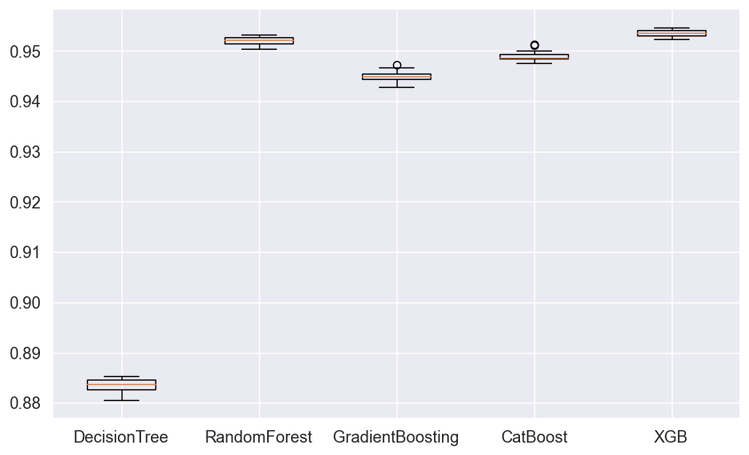

### **5. Interpretación de los Resultados del Modelo Optimizado (XGBoost)**

#### 5.1 Ajuste de Hiperparámetros

Para maximizar el desempeño del modelo **XGBoost**, se llevó a cabo una búsqueda de hiperparámetros utilizando `GridSearchCV`. Este proceso evaluó diferentes combinaciones de hiperparámetros con validación cruzada estratificada (5 pliegues) para identificar la configuración que proporciona el mejor desempeño en términos de **AUC-ROC**. Los hiperparámetros optimizados fueron los siguientes:

- **`colsample_bytree`:** 1.0
- **`learning_rate`:** 0.2
- **`max_depth`:** 6
- **`n_estimators`:** 100
- **`subsample`:** 0.8

El modelo optimizado logró una **puntuación AUC de 0.9537** durante la validación cruzada, confirmando que esta configuración mejora el rendimiento predictivo del modelo.

#### 5.2 Evaluación del Modelo Optimizado

El modelo ajustado fue evaluado en el conjunto de prueba independiente para validar su capacidad de generalización. Los resultados de las métricas clave son los siguientes:

- **Accuracy:** 0.9342 (93.42%)
- **ROC AUC:** 0.9542 (95.42%)

Estas métricas reflejan un excelente rendimiento del modelo, tanto en la clasificación general como en la discriminación entre clases (**abandono** y **no abandono**).

#### 5.3 Reporte de Clasificación

### Análisis Detallado de las Métricas por Clase

| Métrica | Clase "No Abandono" (0) | Clase "Abandono" (1) |
| --- | --- | --- |
| **Precision** | 0.99 | 0.90 |
| **Recall** | 0.86 | 0.99 |
| **F1-Score** | 0.92 | 0.94 |

#### Interpretación

1. **Precisión:**
   - Para la clase "No Abandono", el modelo identifica correctamente el **99%** de los clientes predichos como no abandonados.
   - Para la clase "Abandono", el modelo identifica correctamente el **90%** de los clientes predichos como abandonados.
2. **Recall:**
   - Para la clase "No Abandono", el modelo captura el **86%** de los clientes verdaderamente no abandonados, mientras que el **14%** restante se clasifica erróneamente como abandono.
   - Para la clase "Abandono", el modelo captura el **99%** de los clientes que realmente abandonaron, un resultado sobresaliente en términos de minimizar falsos negativos.
3. **F1-Score:**
   - La métrica F1 es equilibrada entre precisión y recall, mostrando que el modelo mantiene un rendimiento sólido en ambas clases.

#### 5.4 Matriz de Confusión

### Matriz de Confusión

La matriz de confusión ofrece una visualización detallada de las predicciones del modelo:

|  | Predicho: No Abandono | Predicho: Abandono |
| --- | --- | --- |
| **Real: No Abandono** | 38,619 | 6,324 |
| **Real: Abandono** | 324 | 55,775 |

#### Interpretación

1. **Falsos Positivos (6,324):** Representan clientes que no abandonaron pero fueron clasificados erróneamente como abandono. Este número es bajo en relación con el tamaño de la clase.
2. **Falsos Negativos (324):** Representan clientes que abandonaron pero fueron clasificados como no abandono. Este número es notablemente bajo, lo que destaca la efectividad del modelo en minimizar errores críticos para esta clase.
3. **Verdaderos Positivos (55,775):** La gran mayoría de los clientes que abandonaron fueron correctamente identificados.
4. **Verdaderos Negativos (38,619):** La mayoría de los clientes que no abandonaron también fueron clasificados correctamente.

#### 5.5 Conclusión

El modelo optimizado de **XGBoost** presenta un desempeño excepcional en la predicción de abandono de clientes. Los resultados clave incluyen:

- **Capacidad predictiva sólida:** Con un **AUC-ROC de 0.9542**, el modelo discrimina eficazmente entre clientes que abandonan y no abandonan.
- **Balance entre clases:** Tanto la precisión como el recall son altos para ambas clases, mostrando que el modelo no está sesgado hacia una clase en particular.
- **Baja tasa de falsos negativos:** La capacidad para identificar el **99%** de los clientes que abandonan asegura que las estrategias de retención puedan enfocarse de manera efectiva en los clientes en riesgo.

```
Fitting 5 folds for each of 32 candidates, totalling 160 fits
Mejores parámetros encontrados: {'colsample_bytree': 1.0, 'learning_rate': 0.2, 'max_depth': 6, 'n_estimators': 100, 'subsample': 0.8}
Mejor puntuación AUC: 0.9536698171781666
```

```
Accuracy: 0.934205577878506
ROC AUC: 0.9541588373836126
Classification Report:
               precision    recall  f1-score   support

         0.0       0.99      0.86      0.92     44943
         1.0       0.90      0.99      0.94     56099

    accuracy                           0.93    101042
   macro avg       0.94      0.93      0.93    101042
weighted avg       0.94      0.93      0.93    101042

Confusion Matrix:
 [[38619  6324]
 [  324 55775]]
```

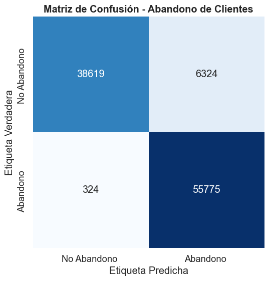

### **6. Modelo de Deep Learning para la Predicción de Abandono**

#### 6.1 Arquitectura y Entrenamiento del Modelo

Para abordar el problema del abandono de clientes, se utilizó una **red neuronal artificial (ANN)** diseñada para clasificar clientes como abandonados o no abandonados. La arquitectura del modelo incluye:

- **Capa de entrada:**
  - 64 neuronas con función de activación **ReLU** que capturan características del conjunto de datos.
- **Capas ocultas:**
  - **Primera capa oculta:** 32 neuronas con **ReLU**, seguida de un **Dropout** del 30% para prevenir el sobreajuste.
  - **Segunda capa oculta:** 16 neuronas con **ReLU**, también seguida de un **Dropout** del 30%.
- **Capa de salida:**
  - Una neurona con función de activación **sigmoid** para producir una probabilidad entre 0 y 1, adecuada para la clasificación binaria.

El modelo fue compilado utilizando:

- **Optimizador:** Adam, que ajusta dinámicamente la tasa de aprendizaje para un entrenamiento eficiente.
- **Función de pérdida:** binary_crossentropy, ideal para problemas de clasificación binaria.
- **Métrica:** accuracy para monitorear el desempeño del modelo durante el entrenamiento.

El entrenamiento se realizó durante **50 épocas** con un tamaño de **batch** de 32 y una proporción de validación del 20%. Además, se fijó una semilla para garantizar la reproducibilidad de los resultados.

#### Resultados en el conjunto de prueba:

- **Pérdida:** No reportada explícitamente, pero reflejada en métricas de evaluación.
- **Precisión:** 93.3%.

El modelo logra un nivel de precisión consistente al clasificar clientes correctamente como abandonados o no abandonados.

#### 6.2 Evaluación del Modelo en el Conjunto de Prueba

Después del entrenamiento, el modelo se evaluó en un conjunto de prueba independiente, y las métricas clave se calcularon para validar su rendimiento.

#### 6.2.1 Métricas Generales

- **ROC AUC:** 0.9525 Este valor, cercano a 1, indica una excelente capacidad para discriminar entre clientes que abandonan y no abandonan.
- **F1-Score:** 0.9434 Combina precisión y recall, mostrando un equilibrio sólido entre ambas métricas.

#### 6.2.2 Reporte de Clasificación

| Métrica | Clase "No Abandono" (0) | Clase "Abandono" (1) |
| --- | --- | --- |
| **Precisión** | 0.99 | 0.90 |
| **Recall** | 0.86 | 1.00 |
| **F1-Score** | 0.92 | 0.94 |

#### Interpretación

- **Precisión:**
  - Para la clase "No Abandono", el modelo predice correctamente el **99%** de los clientes clasificados como no abandonados.
  - Para la clase "Abandono", el modelo clasifica correctamente al **90%** de los clientes predichos como abandonados.
- **Recall:**
  - Para la clase "No Abandono", captura el **86%** de los clientes que realmente no abandonaron.
  - Para la clase "Abandono", captura el **100%** de los clientes que realmente abandonaron.
- **F1-Score:**
  - La métrica F1 de la clase "Abandono" es alta (**0.94**), lo que demuestra que el modelo logra un excelente equilibrio entre precisión y recall.

#### 6.3 Matriz de Confusión

#### Matriz de Confusión

La matriz de confusión muestra la distribución de las predicciones del modelo:

|  | **Predicho: No Abandono** | **Predicho: Abandono** |
| --- | --- | --- |
| **Real: No Abandono** | 38,467 | 6,514 |
| **Real: Abandono** | 194 | 55,867 |

#### Interpretación

- **Verdaderos Negativos (38,467):** El modelo identifica correctamente a la mayoría de los clientes que no abandonaron.
- **Falsos Positivos (6,514):** Representan clientes que no abandonaron pero fueron clasificados erróneamente como abandono.
- **Falsos Negativos (194):** El modelo clasifica incorrectamente a 194 clientes que abandonaron como no abandono, lo cual es un número muy bajo, reflejando una capacidad robusta para minimizar falsos negativos.
- **Verdaderos Positivos (55,867):** La gran mayoría de los clientes que abandonaron fueron correctamente identificados.

#### **6.4 Conclusiones sobre el Modelo de Deep Learning**

#### Desempeño del Modelo de Red Neuronal

El modelo de red neuronal logra un desempeño excepcional en la predicción de abandono de clientes:

1. **Capacidad predictiva sólida:**
   - Un AUC de **0.9525** confirma que el modelo es altamente eficaz para distinguir entre clientes que abandonan y no abandonan.
2. **Balance entre precisión y recall:**
   - Tanto la clase "Abandono" como la clase "No Abandono" tienen métricas sólidas, con un F1-Score de **0.94** para la clase "Abandono".
3. **Baja tasa de falsos negativos:**
   - Solo **194** clientes que abandonaron no fueron detectados, lo que asegura que el modelo es confiable para identificar clientes en riesgo de abandonar.
4. **Reproducibilidad:**
   - La inclusión de una semilla fija permitió garantizar la consistencia en los resultados obtenidos durante cada ejecución del modelo.
5. **Overfitting controlado:**
   - El uso de **Dropout** en las capas ocultas contribuyó a prevenir el sobreajuste, permitiendo un buen rendimiento en el conjunto de prueba.

```
Semilla fija: 1234
```

```
ROC AUC: 0.9525354804944088
F1 Score: 0.9433646848246399
Classification Report:
               precision    recall  f1-score   support

         0.0       0.99      0.86      0.92     44981
         1.0       0.90      1.00      0.94     56061

    accuracy                           0.93    101042
   macro avg       0.95      0.93      0.93    101042
weighted avg       0.94      0.93      0.93    101042

Confusion Matrix:
 [[38467  6514]
 [  194 55867]]
```

### 7. Productivización del Modelo de Predicción de Abandono de Clientes

#### 7.1 Creación de una API para la Predicción de Abandono

#### Integración Empresarial a través de una API

Para integrar los modelos de predicción de abandono en un entorno empresarial, se puede implementar una **API** que permita realizar predicciones en tiempo real. Esta API serviría como puente entre los sistemas de la empresa y los modelos predictivos, permitiendo que nuevos datos de clientes sean procesados y evaluados para determinar si un cliente está en riesgo de abandonar.

##### 7.1.1 Descripción del Proceso

El flujo básico de la API sería el siguiente:

1. **Entrada:** La API recibirá los datos de clientes (como características demográficas, comportamiento, uso de servicios, etc.) a través de una solicitud HTTP en formato **JSON**.
2. **Procesamiento:** Los datos de entrada se preprocesarán de manera similar a como se hizo durante el entrenamiento de los modelos (por ejemplo, escalado o transformación).
3. **Predicción:** Los modelos entrenados (como **XGBoost** y el modelo de **Deep Learning**) calcularán la probabilidad de abandono. Según la lógica empresarial, se puede definir un umbral para clasificar un cliente como de alto o bajo riesgo de abandono.
4. **Salida:** La API devolverá el resultado de la predicción en formato **JSON**, indicando si el cliente está en riesgo de abandono y la probabilidad asociada.

##### 7.1.2 Código Básico para la API

A continuación, un ejemplo de cómo se podría implementar esta API utilizando **Flask**:

```
import pickle
import tensorflow as tf
from flask import Flask, request, jsonify

# Cargar el modelo XGBoost preentrenado
with open('xgboost_model.pkl', 'rb') as model_file:
    xgb_model = pickle.load(model_file)

# Cargar el modelo de Deep Learning preentrenado
dl_model = tf.keras.models.load_model('deep_learning_model.h5')

# Inicializar la aplicación Flask
app = Flask(__name__)

# Ruta para realizar predicciones
@app.route('/predict', methods=['POST'])
def predict():
    # Recibir los datos de entrada en formato JSON
    data = request.get_json(force=True)

    # Preprocesar los datos de entrada (por ejemplo, escalado)
    # Aquí se debe incluir el mismo escalado utilizado durante el entrenamiento
    features = scaler.transform([data['features']])  # Suponiendo que scaler es el objeto de preprocesamiento

    # Realizar predicciones con ambos modelos
    xgb_prediction = xgb_model.predict_proba(features)[:, 1]
    dl_prediction = dl_model.predict(features)[0, 0]

    # Combinar predicciones si es necesario o devolverlas individualmente
    result = {
        'xgboost_prediction': float(xgb_prediction),
        'deep_learning_prediction': float(dl_prediction)
    }
    return jsonify(result)

# Ejecutar la aplicación Flask
if __name__ == '__main__':
    app.run(debug=True)
```

### 7.2 Integración Empresarial

#### Integración de la API en el Flujo de Trabajo Empresarial

Una vez desplegada la **API**, puede integrarse en el flujo de trabajo empresarial de la siguiente manera:

- **Conectividad:** Los sistemas de gestión de clientes (**CRM**) pueden enviar solicitudes HTTP con los datos de los clientes para obtener predicciones en tiempo real.
- **Toma de Decisiones Proactiva:** Las predicciones obtenidas pueden ser utilizadas para identificar clientes en riesgo de abandono y aplicar estrategias de retención, como ofertas personalizadas o campañas específicas.
- **Automatización:** Los resultados de las predicciones pueden alimentar sistemas de automatización que actúan de forma inmediata, mejorando la experiencia del cliente.

### 7.3 Monitorización y Mantenimiento del Modelo

#### Estrategia de Monitorización y Mantenimiento

Es crucial establecer una estrategia de monitorización y mantenimiento para asegurar que los modelos de **Machine Learning** y **Deep Learning** sigan siendo efectivos con el tiempo.

##### 7.3.1 Reentrenamiento Periódico

- Reentrenar los modelos regularmente utilizando datos actualizados de los clientes para reflejar cambios en los patrones de abandono.
- Evaluar la necesidad de ajustar los hiperparámetros o la arquitectura del modelo de Deep Learning durante el reentrenamiento.

##### 7.3.2 Almacenamiento de Resultados

- Registrar cada predicción realizada junto con el resultado real (si el cliente abandonó o no).
- Utilizar estos registros para medir continuamente el rendimiento de los modelos y detectar posibles degradaciones.

##### 7.3.3 Métricas de Monitorización

- **ROC AUC y F1-Score:** Evaluar estas métricas periódicamente para asegurarse de que el rendimiento del modelo no se degrada.
- **Alertas:** Configurar alertas para detectar un aumento significativo en los falsos negativos (clientes en riesgo no detectados) o falsos positivos (clientes incorrectamente clasificados como en riesgo).

### 7.4 Comparación de Modelos y Elección Final

Aunque ambos modelos son comparables, la elección entre ellos dependerá del caso de uso:

- **XGBoost:** Más eficiente computacionalmente y fácil de interpretar, ideal para implementaciones rápidas.
- **Deep Learning:** Capaz de capturar patrones más complejos en los datos, ideal para conjuntos de datos grandes y escenarios dinámicos.

### 7.5 Conclusión

La implementación de los modelos de predicción de abandono mediante una **API** permite integrar estas herramientas en un entorno empresarial. Esto proporciona a la empresa la capacidad de identificar clientes en riesgo de abandonar y tomar decisiones proactivas en tiempo real.

La combinación de estrategias de **monitorización continua**, **reentrenamiento periódico** y **escalabilidad** asegura que los modelos se mantengan actualizados y efectivos en un entorno cambiante. Esta solución no solo optimiza la retención de clientes, sino que también permite a la empresa anticiparse a las necesidades de los clientes, mejorando la satisfacción y la fidelidad a largo plazo.

### **8. Conclusiones**

En este apartado se presentan las **conclusiones** del proyecto, organizadas en tres secciones: un resumen de los hallazgos más relevantes, las implicaciones prácticas del modelo de predicción de abandono, y recomendaciones para futuros trabajos que busquen mejorar o expandir los resultados obtenidos.

#### 8.2 Implicaciones Prácticas

El desarrollo de estos modelos tiene importantes **implicaciones prácticas** para las empresas que buscan optimizar su retención de clientes:

- **Prevención Proactiva del Abandono:** La capacidad de identificar clientes en riesgo permite a las empresas diseñar estrategias personalizadas para retenerlos, como ofertas específicas, mejoras en la experiencia del cliente o programas de fidelización.
- **Automatización de Decisiones:** La implementación de los modelos mediante una **API** facilita la automatización de la detección de riesgo en tiempo real, lo que permite a los sistemas empresariales actuar rápidamente para reducir la rotación de clientes.
- **Escalabilidad y Flexibilidad:** La integración de los modelos mediante tecnologías como contenedores (**Docker**) o servicios en la nube (**AWS Lambda**, **Google Cloud Functions**) asegura que el sistema pueda manejar un gran volumen de clientes sin comprometer el rendimiento.
- **Reducción de Costes:** Al minimizar falsos positivos y negativos, las estrategias de retención se enfocan en los clientes adecuados, maximizando el retorno de la inversión en campañas de fidelización.

#### 8.3 Recomendaciones para Futuros Trabajos

Aunque los resultados obtenidos son prometedores, existen diversas áreas para mejorar o explorar en futuros trabajos:

- **Exploración de Nuevas Técnicas:** Investigar modelos más avanzados, como redes neuronales recurrentes (**RNN**) o transformers, para mejorar la capacidad predictiva, especialmente en datos longitudinales.
- **Optimización de Hiperparámetros:** Ampliar la búsqueda de hiperparámetros utilizando técnicas como **Random Search**, **Bayesian Optimization** o **AutoML** para maximizar el rendimiento de los modelos.
- **Análisis Temporal:** Incorporar datos históricos de clientes a lo largo del tiempo podría mejorar la capacidad del modelo para capturar patrones relacionados con el abandono a largo plazo.
- **Incorporación de Costes Operativos:** Considerar métricas ajustadas por el coste de falsos positivos y negativos, ayudando a las empresas a priorizar las acciones más rentables.
- **Reentrenamiento y Actualización:** Implementar un proceso continuo de actualización y reentrenamiento de los modelos utilizando datos recientes para adaptarse a cambios en el comportamiento de los clientes.
- **Expansión del Dataset:** Evaluar el modelo en diferentes mercados o industrias para garantizar su generalización y aplicabilidad en contextos diversos.

#### 8.4 Conclusión Final

El desarrollo de modelos predictivos para el abandono de clientes representa una herramienta estratégica crucial para las empresas en la actualidad. Los resultados obtenidos con **XGBoost** y **Deep Learning** demuestran que es posible identificar clientes en riesgo con alta precisión y de manera eficiente. La integración de estos modelos como **APIs** empresariales no solo optimiza la retención de clientes, sino que también mejora la experiencia del cliente y maximiza el retorno de inversión.

En resumen, este proyecto proporciona una solución robusta y escalable para abordar el problema del abandono de clientes, sentando las bases para futuras investigaciones y aplicaciones más avanzadas en el campo del análisis predictivo.